Title: 차세대 염기서열 데이터 분석의 이해와 응용 (Next Generation Sequencing Data Analysis)

# 학습 목표

차세대 시퀀싱 기술은 급속한 발전으로 다양한 응용분야를 창출하고 있다. 제8장에서는 FASTA, FASTQ와 같은 차세대 시퀀싱 데이터의 데이터 포맷, 서열정렬 및 서열조립 기법과 시각화 도구에 대해 알아보고, 얻어진 서열변이(variant)로부터 SNP/InDel 검출 및 다양한 주석달기의 의미를 학습한다. 서열 정렬 (alignment) 알고리듬의 기본을 이루는 Burrow Wheeller Transformation (BWT)과 서열 정보 저장과 탐색의 기본 알고리듬인 서픽스 트리 (suffix tree)를 이해한다. 현재 활발하게 사용중인 전장 엑솜 시퀀싱 기술과 차세대 시퀀싱 기술의 발전 동향을 살펴보고 또 다음 세대 기술로 기대되는 단일 분자 염기서열 분석 기술을 이해한다. (single molecule sequencing)

# 서론

차세대 시퀀싱 (Next Generation Sequencing)이라는 용어는 2007년 솔렉사 사(Solexa 社)가 일루미나사 (Illumina 社) 에 합병되면서 사용되기 시작한 것으로 알려져 있고, 현재는 3세대 및 4세대 제품들이 판매되고 있다. 차세대 시퀀싱 기술의 빠른 보급은 개인 유전체 시대의 개막을 주도했다.

2011년에는 1인 당 whole genome sequencing 30x (coverage)를 기준으로 한 사람당 $4000의 가격이 형성, 2013년에 이르러서는 $1000 genome era가 시작되었다. Drop in genome sequencing cost expedited whole genome sequencing (WGS) of various organisms including humans. 특히 인간 유전체 다양성을 파악하기 위한 연구 사업으로 HapMap과 1000 Genomes Project, ENCODE 사업이 수행되었고, cancer genomic analysis를 이용한 targeted therapeutics의 optimal use를 위한 accompanied diagnostics가 현실화 되었다. 오늘날은 암의 진단분류체계가 기존의 전통적인 세포, 조직 병리학적 (cellular, hito/pathological) classification을 넘어서 molecular 수준의 molecular pathological 분류체계로 변화하고있다.

어떤 유전자에 어떤 변이가 있느냐에 따라 약물선택이 결정될 수 있다는 믿음이 확산되고 있으며, 이를 입증하기 위한 다양한 우산 임상시험 (umbrella trial)이 수행되고 있다. 이를 genomics에 기반한 precision medicine이라고 한다.

그러나 현 시점에서 개인 유전체 서열의 정확도는 아직까지도 연구용 수준 (research-level)에 머물고 있으며 의학적 사용 (medical/clinical/commercial use)을 위한 혁신이 더 필요하다. 2011년 Nature Genetics의 editorial, "Towards a medical grade human genome sequence"는 차세대 시퀀싱 기술의 의학적 활용에 필요한 시퀀싱 수준을 제시했다. 데이터의 질적 수준에 아직은 한계가 있는 한 편, 머지 않아 누구나 신뢰할 수 있는 고품질의 데이터를 personal genome 수준에서 얻을 수 있으리라는 기대가 섞여있다.

개개인의 유전체 데이터 획득비용은 낮아졌으나 역설적으로 바이오 정보학 분석은 더 큰 문제로 지목된다. 1,000불 유전체 시대는 열렸으나, 10만불 분석, 100만불 해석이라는 더 어려운 문제에 마주친 것이다. 서울의대 정보의학실 Bioinformatics Medical Research Center의 genomic data analysis와 해석 파이프라인이다.

1. Reference sequence에 align하여 mapping하는 과정
2. Reference sequence와 비교하여 어떤 genetic variant를 가지는지 variant calling 단계
3. Detected variant에는 모든 available한 interpretation 및 annotation 정보를 부여
   - 변이는 개별적으로만 해석되는 것이 아니고, 변이집합분석 (Gene Set Enrichment Analysis? https://www.gsea-msigdb.org/gsea/index.jsp), 임상적 질병 위험률 분석 (disease risk assessment), 약물유전체학적 분석 (pharmaco-genomic analysis), gene-environment interaction 분석 등 생명정보학의 거의 모든 분석을 수행한다. 이러한 과정에는 고도의 distributed processing, 및 파일 시스템과 클라우드 컴퓨팅 등의 최신 기술의 접목이 필수적이고, 다양한 생물학적 데이터베이스의 통합이 선행되어야 한다. 지난 10여 년에 걸쳐 개발되고 구축된 수많은 생명정보학 tools와 knowledge database의 통합 분석 (integrated analysis)를 통해 궁극적인 해석 단계로 진행해간다.

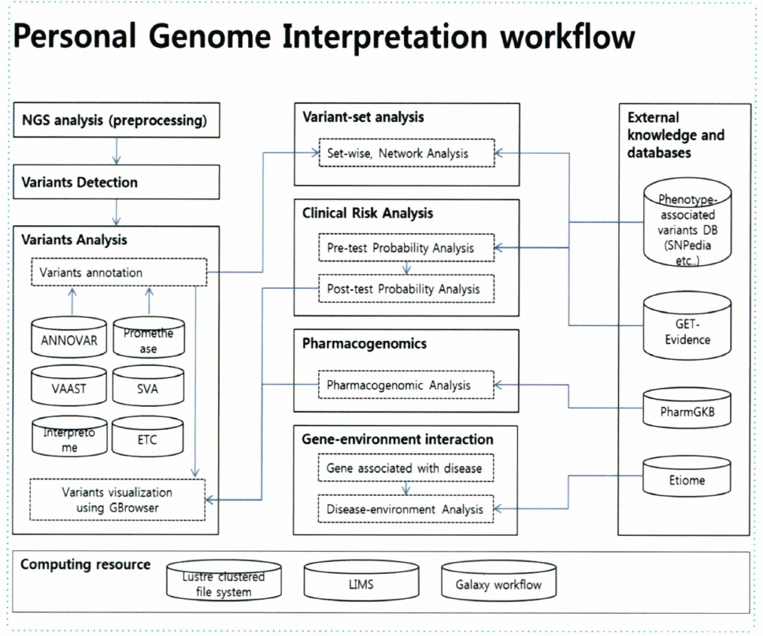

# 차세대 시퀀싱 플랫폼 (NGS platform)

1986년 최초의 자동화된 시퀀서가 등장한 이래로 기술 발전이 계속 되었다. 그동안 모든 sequencer는 Sanger method를 이용하였으나, 최근 새로운 기법의 시퀀싱 기술이 급속히 보급되며 대량의 parallelized data production이 가능해졌다. 이러한 sequencer를 Next Generation Sequencer (NGS)라 한다. 그러나 이제 이 기술이 보급된지 시간이 지남에 따라 NGS라는 term보다 새로운 term으로 부를 필요성이 대두되고 있다. 기종에 따라 약간의 차이는 있지만 기본적으로 1. semented DNA sequence들을 amplification하는 단계 (PCR)와, 2. 형광표식된 서열의 동영상촬영 및 분석 단계가 뒤따른다.

PCR 증폭 방식에 따라서, emulsion PCR (emPCR) 방식을 사용하는 Roche사의 454, Life Technologies사의 기종들과, solid-phase amplification을 사용하는 일루미나 사의 기종들로 나눌 수 있다. 현 시점에서 대표적인 차세대 시퀀서인 일루미나 사와 라이프테크놀로지스 사의 기술을 중심으로 서술하고, 3rd generation sequencing 장비로 분류되는 Oxford Nanopore Sequencer와 Pacific BioSciences사의 PacBio RS II를 포함한 single molecule sequencing and analysis 기술은 후반부에 따로 설명한다.

https://www.intechopen.com/books/next-generation-sequencing-advances-applications-and-challenges/next-generation-sequencing-an-overview-of-the-history-tools-and-omic-applications

[figure not shown]

## Illumina: HiSeq, MiSeq, NextSeq, x-10, NovaSeq 시리즈

1998년 설립된 Solexa는 SBS(Sequencing by synthesis) 기술을 염기서열 시퀀싱에 적용했다. 2007년 Solexa를 합병한 일루미나는 다양한 SBS-based technology들을 개발해왔다. HiSeq 2500은 2 x 125bp 서열 조각에서 6일의 실행시간으로 최대 1Tb의 데이터 생산이 가능하다. 일루미나 사는 전반적으로 낮은 비용으로 많은 데이터를 생산하는 특징을 추구해 왔으며, 대규모 시퀀싱 수행하는 연구 목적으로 많이 사용되어 왔다. 일루미나 사의 bridge amplification technology (bridge PCR)은 슬라이드 (solid matrix slide)위에 DNA fragment를 fixation시킨 후, 최대 1000 분자까지 증폭시켜 같은 서열의 DNA fragment group을 이루는 cluster를 틀로 사용하여 4 fluorescence-labeled deoxynucleotide를 이용한 1 base synthesis reaction인 SBS를 수행한다.

[figure not shown]

경쟁사인 라이프 테크놀로지스 사의 소형 "벤치 탑" 시퀀서인 Ion PGM과 Proton 장비에 대응하여 일루미나는 소형 장비인 MiSeq를 발표했다. MiSeq는 기존 high-capacity sequencer인 HiSeq의 기술을 그대로 적용하면서 소형화에 성공하여 장비 크기와 가격을 줄이고 효율적인 작업을 가능케했다.

- Ion PGM, Proton은 ion semiconductor sequencing 기술이 적용된 제품으로, sequencing by synthesis 방법의 일종이나, synthesis 시에 생기는 PPi+H+ 에서 원래는 PPi를 pyrosequencing으로 측정했으나 optics가 사용되지 않고 그것이 아닌 H+ concentration increase를 semiconductor를 이용하여 측정하는 방식을 택했다.

NextSeq500은 기존 Illumina SBS반응에 4가지 형광염료가 사용된 것과 달리 2가지 형광염료가 사용된다. NextSeq 500은 C(Red), T(Green), A(Mix of Red and Green = Yellow), G(No fluorescence)로 표지하여 fluorescent dye의 개수가 반으로 줄기 때문에 sequencing cost도 줄일 수 있었다.

한편, whole genome sequencing에 강점을 가진 미국 Complete Genomics사가 중국 BGI에 인수되면서 대응하기 위해 Illumina에서 HiSeq X-10이라는 개인 유전체 분석 전용 장비도 함께 개발하여, 일루미나 사는 MiSeq, NextSeq, HiSeq 2500, HiSeq X-10의 네가지 라인업을 갖게 되었다. HiSeq X-10은 3일 실험으로 16명의 Human Whole Genome의 30배수 시퀀싱에 해당하는 1.8TB의 데이터를 생산할 수 있고, 연간 18000명의 개인 유전체 시퀀싱이 가능하다. 하지만 대형 연구에 특화된 X-10은 최소 10대의 장비를 동시 구매하고 operate해야하며 이는 Complete Genomics 사가 장비의 소형화를 실현하지 못하고 100억~200억에 달하는 고가 시설의 설치가 필요했던 약점을 고려한 전략적 대응으로 해석된다. 일리무나 사의 시퀀싱 데이터는 FASTQ 파일로 저장된다.

# Thermo Fisher사의 반도체 시퀀서 시리즈

Life Technologies사의 Ion Torrent는 semiconductor 기반의 소형 시퀀서인 PGM (Personal Genome Machine)을 등장시켜 소형 "벤치탑" 시퀀서를 유행시켰다. (쪼끄맣고 책상에 올려놓을 수도 있는 개인용 시퀀서!) Emulsion PCR로 amplification한다는 점에서 타 NGS와 유사하지만, fluorescent artificial nucleotide를 사용하고 빛을 인식하는 방식이 아니라, 반도체 칩의 작은 구멍에서 일어나는 DNA synthesis 과정에서 서로 다른 염기가 결합할 때 발생하는 pH의 변화를 직접 반도체에서 전기적 신호로 transformation한다는 점이 특징이다.

[figure not shown]

기존 시퀀서에서 필수적인 artificial fluorescence nucleotide, video recording 및 image processing 단계가 생략되므로 작고 저렴한 시퀀서의 보급이 가능해졌고, 시퀀싱과 분석을 3시간 정도에 완료하는 효율적인 장비가 되었다. 이러한 특징으로 Ion Torrent sequencer는 expedited, small-batch sequencing이 필요한 임상 적용 (clinical application)에 특화되었다고 볼 수 있다.

Ion PGM과 Ion Proton의 두가지 플랫폼에서 집적도가 다른 반도체 칩을 사용해온 Thermo Fisher사는 최근 Ion Torrent S5, S5 /XL이라는 모델을 발표하며 통합된 하나의 플랫폼에 세가지 칩을 선택가능한 방식으로 제공하여 2시간 반만에 400 base 길이의 20 million sequence fragments 또는 200 base의 80 million sequence fragment를 획득할 수 있도록 한층 효율성이 증대되었다.

위의 그림에서 나타나 있듯이 한 번의 signal detection과 washing, 및 그 다음 순서의 nucleotide 진입 주기가 몇 초 내에 이루어져 고속 시퀀싱이 가능하다. 반면 문제점은 homopolymer 서열의 경우 그 연속되 갯수의 산정에 어려움을 겪어 InDel에 대한 error가 상대적으로 높다는 단점이 있다. Ion Torrent 장비는 빠른속도와 저렴한 가격, 고도의 자동화를 통한 편리한 사용법으로 target sequencing을 통한 새로운 diagnostic test 개발에 장점을 갖는다.

ex.) SARS-CoV-2

# 차세대 시퀀서의 의료 진단장비 인증과 실험기법의 안정화

- MiSeqDx(Illumina) + Universal Kit reagents + MiSeqDx Cystic Fibrosis 139-Variant Assay + MiSeqDx Cystic Fibrosis Clinidal Sequencing Assay
- Ion PGM Dx (Life Technologies: Class II medical instrument)
- Illumina HiSeq rapid v2 Reagent kit: 기존 150bp 까지 sequencing할 수 있던 것을 200~250bp로 늘렸다.
- Hi-QTM: Improved version of Ion Torrent, with significant improvement in avoiding InDel errors. 미국 FDA는 2013년 11월 최초로 Illumina의 MiSeqDx를 이용한 Universal Kit reagents와 유전성 질환인 cystic fibrosis의 두가지 진단 기법인 "MiSeqDx Cystic Fibrosis 139-Variant Assay"와 "MiSeqDX Cystic Fibrosis Clinidal Sequencing Assay"의 임상 의료 진단용 사용을 승인헀다. 이는 CFTR (cystic fibrosis transmembrane conductance regulator)의 변이분석을 수행한다. 일루미나의 뒤를 이어 2014년 9월 라이프테크놀로지스 사의 Ion PGM Dx가 미국 FDA의 Class II 의료 장비로 등재되었다.

안정적 실험 결과를 얻기 위한 발전도 이어졌다. 2014년 도입된 Illumina HiSeq Rapid v2 Reagent Kit는 기존의 150bp에서 200~250bp로 늘어난 염기서열 단편을 얻을 수 있게 되었다. -> 좀더 alignment/mapping에 있어 정확도 높아질 듯.

비슷한 시점에 Life Technologies사에서 도입한 Hi-QTM은 새로운 DNA polymerase를 사용하여 Ion Torrent 시스템의 약점이던 InDel 에러율을 최소화 하였다. 회사의 공식 발표에 따르면 에러율이 S. aureus에서 94%, E. coli에서 80% 감소했고, 2300개의 target amplicon 방식 실험에서는 43% 감소했음을 보고했다.

# 데이터 포맷과 염기서열 정렬 (Data Formats and Sequence Alignment)

차세대 시퀀싱 서열 데이터를 다루기 위해서 데이터 포맷에 대한 이해가 필요하다. Sequence information과 quality score가 추가된 형태의 데이터가 생성된다.

## FASTQ 포맷

Wellcome Trust Sanger Institute에서 개발된 sequence storage file format이다. NGS의 등장으로 Illumina 등이 사용해왔고, 현재는 Life Technologies사의 Ion Torrent 등에서도 사용된다. FASTA 포맷의 각 염기에 QV가 추가되어 통합된 하나의 파일이 FASTQ 포맷이 된다.

**FASTQ = FASTA + Quality Score**

모든 점수를 한 문자로 나타내기 위하여 QV에는 숫자 외에 다양한 ASCII code 문자가 사용된다.

!"#$%&'()*+,-./0123456789:;<=>?@ABCDEFGHIJKLMNOPQRSTUVWXYZ[\]^_`abcdefghijklmnopqrstuvwxyz{|}~

FASTA format은 서열 구분자 ">"로 구분되는 한 행의 서술문과 다음 행부터 이어지는 서열 데이터로 구성된다. 구분자 ">" 다음에는 서열 아이디와 서술이 위치하는데 둘 다 선택사항이며, ">" 다음에는 공백없이 붙여서 서열의 아이디가 표기되고 아이디들은 분리 문자열, "|"로 배열된다. 한 줄의 길이는 80자 이내를 권장하며, 서열 구분자 ">"를 만나게 되면 앞서의 서열은 끝난 것이고 새로운 서열이 시작되는 것으로 간주한다. FASTA 포맷에 대한 자세한 설명은 chapter 9에서.

**FASTA format**

```
>AB000263 |acc=AB000263|descr=Homo sapiens mRNA for prepro cortistatin like peptide, complete cds.|len=368
ACAAGATGCCATTGTCCCCCGGCCTCCTGCTGCTGCTGCTCTCCGGGGCCACGGCCACCGCTGCCCTGCC
CCTGGAGGGTGGCCCCACCGGCCGAGACAGCGAGCATATGCAGGAAGCGGCAGGAATAAGGAAAAGCAGC
CTCCTGACTTTCCTCGCTTGGTGGTTTGAGTGGACCTCCCAGGCCAGTGCCGGGCCCCTCATAGGAGAGG
AAGCTCGGGAGGTGGCCAGGCGGCAGGAAGGCGCACCCCCCCAGCAATCCGCGCGCCGGGACAGAATGCC
CTGCAGGAACTTCTTCTGGAAGACCTTCTCCTCCTGCAAATAAAACCTCACCCATGAATGCTCACGCAAG
TTTAATTACAGACCTGAA
```

1st line: information

2nd line 부터 data.

**FASTQ format**

```
@SEQUENCE_ID
GTGGAAGTTCTTAGGGCATGGCAAAGAGTCAGAATTTGAC
+
FAFFADEDGDBGEGGBCGGHE>EEBA@@=
```

1st line: a '@' character, followed by a sequence identifier and an optional description

2nd line: the raw sequence letters.

3rd line: a '+' character, optionally followed by the same sequence identifier (and any description)

4th line: quality values for the sequence in Line 2

## QV (Quality value or quality score) 개념

QV에는 오래전부터 서열분석 분야에서 사용된 "Phred quality score"의 개념을 따른다. 이는 error rate의 log를 취하여, sequencing 시 10은 10%의 오류가 발생할 확률, 20은 1%의 오류가 발생할 확률, 30은 0.1%의 오류 발생 확률을 의미한다.

$$ Q = -10 \log_{10}{P}$$

| Phred Quality Score | Probability of incorrect base call | Base call accuracy |
| --- | --- | --- |
| 10 | 1 in 10 | 90% |
| 20 | 1 in 100 | 99% |
| 30 | 1 in 1000 | 99.9% |
| 40 | 1 in 10,000 | 99.99% |
| 50 | 1 in 100,000 | 99.999% |
| 60 | 1 in 1,000,000 | 99.9999% |

어떤 sequencer의 base calling accuracy가 99.99%라면, 1 in 10000의 error rate을 가지므로 reads data 대부분의 QV가 40 이상이었다는 의미이다.

그런데 유의해야할 점은, QV가 어떤 absolute한 quality evaluation measure가 아니라는 것이다. 장비마다 데이터 생산 메커니즘이 다 다르고, 따라서 어떤 신호가 어떻게 검출되어 어느 정도의 accurate base call/color call로 이어지는지에 대한 자체적인 분석과 machine learning을 기반으로 도출되는 통계값이기 때문이다. 따라서 사용되는 regression 모델에 따라서도 다를 수 있다. 그러므로 개념은 같지만 서로 다른 기종의 QV를 있는 그대로 비교하는 것은 오류의 위험성이 크다. (같은 sample을 다른 sequencer에서 normalization하기 위해 돌리는 것으로 해결 될 수도?)

## Sequence Alignment

고속 서열정렬 알고리듬은 mapping 속도를 높이기 위해 index (색인)이라는 보조적 자료구조를 생성한다. 책에서 원하는 위치를 찾는데 색인이 도움이 되는 것처럼, 거대한 DNA 염시서열의 색인은 short fragment sequence가 DNA sequence안에 위치한 곳에 대한 빠른 검색을 가능하게 한다.

색인의 종류

- hash table 기반: key-value 해쉬함수
- suffix tree 기반: 문자열 S의 모든 suffix를 트리에 저장하는 데이터 구조

현재까지 소개된 대부분의 도구들은 단편서열에 특화된 정렬 도구로써 단편의 길이가 길어질 경우 높은 성능을 낼 수 없다. 또한 대부분 gap 허용 범위가 제한적이어서 reference genome과 gap으로 인한 차이가 큰 genome sequencing data의 경우 올바른 mapping이 어렵다.

### 해쉬 테이블 기반의 (Hash table-based) sequence alignment

Hash table index 구축 방법은 일반적으로 염기서열의 각 위치를 동일 길이의 k-tuple로 잘라서 그 위치 정보와 함께 해쉬테이블에 저장하여 색인을 구축한다.

example

```
S = "banana"

k = 4

모든 k-tuple의 집합? {"bana", "anan", "nana"}
```

index에 따른 hash table을 만들면 index와 value가 1대1로 hash mapping을 통해 연결되며, complexity는 average case에 대해 O(1)이다.

다음은 hash function의 작동 방식을 나타낸 그림이다. 이때 hash 값이 두개의 key 값에 대해 동일하게 나타나면 collision이 일어났다고 한다.

[figure not shown]

Hash에 대한 further explanation:

- [cheapsslsecurity.com](https://cheapsslsecurity.com/blog/decoded-examples-of-how-hashing-algorithms-work/#:~:text=A%20hash%20function%20is%20a,fixed%20length%20%E2%80%93%20the%20hash%20value.)
- [자료구조: hash table](https://k39335.tistory.com/18)

**Seed and Extend**

DNA의 염기는 A, G, C, T로 구성되므로 k-tuple의 총 개수는 최대 4**k개가 된다, 또한 그 위치정보의 수는 염기서열의 길이와 비슷해진다. 알고리듬에 따라 reference genome 또는 query sequence 색인을 구축하여 사용한다. 해쉬 테이블 기반의 정렬은 query sequence와 reference sequence 사이에서 정확히 일치하는 seed sequence를 해쉬 테이블을 이용해 찾고, 그 지점을 출발점으로 삼아 서열 정렬을 수행한다. 이러한 방법을 "seed-and-extend"방식이라 한다.

**Spaced seed**

Bin Ma는 k개의 비연속적인 문자를 씨앗서열 (seed sequence)로 사용할 것을 제안하고 k개 문자의 상대적 위치를 model, k를 모형의 weight이라 정의했다. 예를 들어 가중치 6인 서열 모형 1110111의 경우 "actgact"와 "actgact"뿐 아니라 "actgact"와 "acttact"등도 씨앗서열과 일치한다. 왜냐면 4번째 position의 weight이 0으로 되어있기 때문에 mismatch가 있어도 ignore하게 된다. 이렇게 정의된 "spaced seed" 전략을 사용하면 전체가 연속으로 일치하는 classical seed sequence와 비교하여 sensitivity가 향상된다고 보고되었다. (match를 검출할 확률이 높아짐.)

### 서픽스 트리 기반의 (Suffix tree-based) Sequence Alignment

Suffix는 string의 substring 중 prefix와 반대로 문자열의 후반부에 위치하는 부분문자열이다. 예를 들어 "banana"에 대해 "nana"가 suffix이다. Suffix tree는 문자열의 모든 서픽스를 소유하는 트리 구조를 말하며, 문자열 관련 연산 효율을 매우 높일 수 있는 자료구조이다.

"banana"로 서픽스 트리를 만드는 경우 "banana", "anana", "nana", "ana", "na", "a" 여섯 개의 서픽스를 모두 가져야 한다. 이 때 "ana"는 "anana"의, "na"는 "nana"의, "a"는 다시 "anana"의 prefix이므로 효율적인 suffix tree는 자기 자신과 "anana", "nana"만으로 구성 가능하게 되어, 작은 repeating pattern을 효과적으로 탐색할 수 있게 된다. "$"표시는 suffix의 종결 위치를 표기한다.

Python Implementation of Suffix Tree: https://github.com/kvh/Python-Suffix-Tree

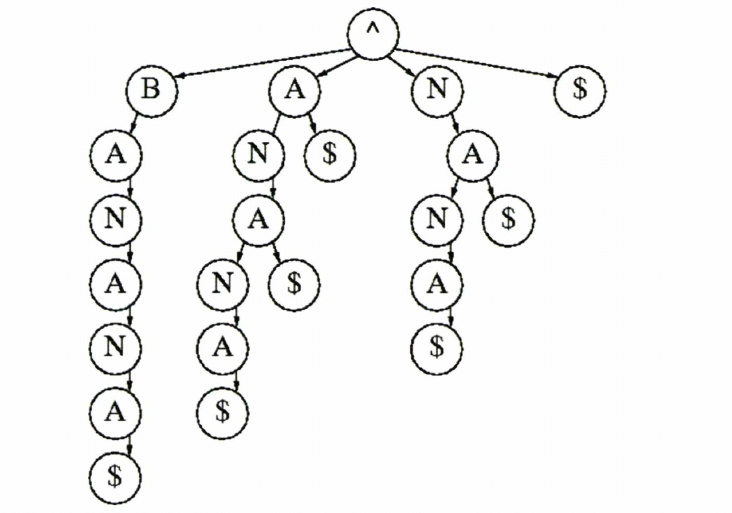

```python
string = input()
substrings = []
for i in range(len(string)):
    substrings.append(string[-(i+1):])
```

```
mississippi
```

```python
substrings
```

```
['i',
 'pi',
 'ppi',
 'ippi',
 'sippi',
 'ssippi',
 'issippi',
 'sissippi',
 'ssissippi',
 'ississippi',
 'mississippi']
```

```python
characters = [char for char in string]
```

```python
characters
```

```
['m', 'i', 's', 's', 'i', 's', 's', 'i', 'p', 'p', 'i']
```

```python
characters_set = set(characters)
```

```python
characters_set
```

```
{'i', 'm', 'p', 's'}
```

```python
from collections import defaultdict
suffix_tree = defaultdict(defaultdict)
```

```python
suffix_tree
```

```
defaultdict(collections.defaultdict, {})
```

```python
suffix_tree = dict()
```

```python
for char in characters_set:
    for substring in substrings:
        if char == substring[0]:
            if char not in suffix_tree:
                suffix_tree[char] = []
            suffix_tree[char].append(substring)
```

```python
suffix_tree
```

```
{'p': ['pi', 'ppi'],
 'i': ['i', 'ippi', 'issippi', 'ississippi'],
 'm': ['mississippi'],
 's': ['sippi', 'ssippi', 'sissippi', 'ssissippi']}
```

이게 아니긴 한데... 일단 보류.

### Burrows-Wheeler Transform (BWT)-based Alignment

원본 문자열 전체를 서픽스 트리로 구출할 경우 완성된 **트리의 크기 (storage size)가 매우 커지는 문제점**을 갖고 있다. 이러한 문제점을 극복하기 위해 **suffix array**는 사전상으로 정렬된 서픽스의 시작 위치를 저장하는 자료구조로 서픽스 트리와 비교하여 공간효율이 높다. BWT는 1994년 Michal Burrows와 David Wheeler가 개발한 문자열 순서 변환 알고리즘이다. BWT 알고리즘으로 변환하여 압축하는 텍스트는 좋은 효율로 압축 가능하다. 문자들의 순서를 재배치한 BWT의 결과물이 반복문자가 많은 문자열로 변환되는 성질이 있기 때문이며 이는 반복이 많은 문자열은 일반적으로 압축효율이 좋기 때문이다.

Reference: https://web.stanford.edu/class/cs262/archives/notes/lecture4.pdf

BWT는 본래 데이터 압축을 위한 transformation으로 개발되었지만, 필요한 메모리 공간이 매우 적어 현재 많은 차세대 염기서열 정렬 도구에 적용되고 있다. Suffix tree, suffix array, BWT-based indexing은 모두 문자열의 suffix를 저장하는 자료구조로 부분 문자열이 원래 문자열에 여러 곳에 나타나더라도 한 번에 찾을 수 있는 장점을 가진다.

NGS데이터의 정렬을 위한 초기 알고리즘들은 hash table 기법 (eg., Eland, SOAP, Maq 등)을 많이 활용했으나 특성상 메모리 사용량을 줄이는 것이 중요하므로 최근에는 BWT 알고리즘에 기반한 서열정렬 알고리즘 (Bowtie BWA and soap2)들이 다수 발표되고 있다.

BWT Class

```python
class BTW(object):
    def __init__(self, s=""):
        self.string = s
        self.container = []

    def adapter(self, string):
        return string+"$"

    def forward(self):
        string = adapter(self.string)
        temp = []
        for i in range(len(string)):
            temp.append(string)
            string = string[-1]+string[:-1]

        temp.sort()

        for j in temp:
            self.container.append(j[-1])

        return "".join(self.container)

    def reverse(self, s = None):
        if s == None:
            copied = self.container.copy()
            for i in range(len(self.container)-1):
                copied.sort()
                for j in range(len(copied)):
                    copied[j] = self.container[j]+copied[j]

            for item in copied:
                if item.endswith("$"):
                    return item

        else:
            copied = [char for char in s]
            for i in range(len(s)-1):
                copied.sort()
                for j in range(len(copied)):
                    copied[j] = s[j]+copied[j]

            for item in copied:
                if item.endswith("$"):
                    return item
```

```python
new_btw = BTW(s="BANANA")
```

```python
new_btw.forward()
```

```
'ANNB$AA'
```

```python
new_btw.reverse()
```

```
'BANANA$'
```

```python
btw = BTW(s="ctaaagaaatcaaaatgccgcacaaggtaagtaacgtcacgctagcgaagctcttccgat")
```

```python
btw.forward()
```

```
'tctgatagctaaccaataaagaatagttggccaa$ggtaccctacaaagcacggcagtcac'
```

```python
btw.reverse(s="tctgatagctaaccaataaagaatagttggccaa$ggtaccctacaaagcacggcagtcac")
```

```
'ctaaagaaatcaaaatgccgcacaaggtaagtaacgtcacgctagcgaagctcttccgat$'
```

Bash script로 파이프라인 짜서 여러개를 한번에 돌리는 연습을 해야한다.

```python
btw2 = BTW(s="ABDABAAAABBBCCBBABDDBDDDBABBABBBBDDABABABDABABDBAAB")
```

```python
btw2.forward()
```

```
'BBABAADDBDBBA$BBBAADADBAABACAABBBBAAABADCBBDBBDDBDBB'
```

```python
btw2.reverse()
```

```
'ABDABAAAABBBCCBBABDDBDDDBABBABBBBDDABABABDABABDBAAB$'
```

# 차세대 시퀀싱의 응용

차세대 시퀀싱 기술은 분석 효율성 극대화를 통해 그간 특정 종의 reference genome sequence를 구축하기 위한 목적으로 수행되어 온 인간 유전체 사업을 포함한 많은 유전체 사업을 완수하고, 이제 개체간 variant나 disease-related variant로 지목되는 SNV, CNV, splicing variant 검출 등의 다양한 목적으로 확장되었다. 이처럼 1차 분석이 완료된 종에 대한 다양한 분석을 resequencing이라고 한다. (ex. Reference genome과 비교하여 개체마다 어떤 부분에 어떤 변이가 있는가?)

Clinical exome sequencing, CES는 최근 차세대 시퀀싱의 가장 중요한 응용 분야의 하나로 자리잡았다. Exome을 microarray hybridization을 이용하여 capture하여 NGS를 돌려 희귀 유전 질환 (rare genetic disorder)을 앓는 환자를 대상으로 한 전장 엑솜 시퀀싱 (Whole Exome Sequencing)을 적용한다. 2014년 발표된 한 연구결과는 유전질환이 추정되는 814명 중 약 26%의 경우에 clinical exome sequencing으로 정확한 diagnostics가 가능했다고 보고했다. 또한 대상 환자의 유전체만 분석하는 Proband CES보다 환자와 그 부모를 함께 분석하는 Trio CES가 de novo variant와 compound heterozygous variant를 올바르게 찾아낼 성공률이 더 높았다.

세포 없는 DNA (cell-free DNA) 연구도 최근 각광을 받는다. 장기 이식 수술의 경우 장기 뿐 아니라 DNA도 함께 이식되며, host graft-rejection으로 transplanted tissue/organ이 공격을 받아 손상되면 환자의 혈액으로 damaged tissue의 DNA가 유리된다. 따라서 recipient의 혈액에서 donor의 cell-free DNA가 검출되면 조기에 graft rejection 여부를 판단할 수 있어 큰 도움이 된다. Cell-free DNA 연구의 또 다른 응용 분야는 임산부의 혈액에서 발견되는 태아의 세포없는 DNA이다. Amniocentesis는 주사기로 직접 산모의 양막을 puncture하여 양수를 직접 획득하는 검사로, invasive하며 굉장히 위험한데, 산모 혈액 내의 태아 cell-free DNA를 검사하면 non-invasive prenatal testing이 가능하여 fetal safety의 획기적인 향상이 가능하다. 현재 Down syndrome의 diagnostics가 매우 높은 신뢰도로 태아의 산모 혈액내 세포 없는 DNA 검사로 가능함이 확인되었고, 다양한 trisomy 검사에서 성공적인 연구결과가 보고되고 있다. 이론적으로는 거의 모든 태아의 DNA abnomrality를 검사할 수 있으므로 매우 활발하게 clinically applied되고 있는 분야이다.

Single-cell genomics 또한 NGS 기술 발전에 힘입어 급부상하고 있는 분야이다. 기술 발달로 미량의 DNA 시료로 (약 7pg/cell) whole genome sequencing이 가능해졌다. Single cell의 DNA를 분석하면 cell lineage tree 구축도 가능해지고 (phylogenetics of cell evolution), 특히 세포의 변화가 변화무쌍한 developmental biology와 cancer heterogeneity 연구 발전에 꼭 필요한 기술로 평가된다.

자궁경부암을 일으키는 HPV (Human Papilloma Virus) DNA를 검출하는 것과 같은 pathogen의 DNA를 직접 검출하는 것도 유망한 분야이다. 나아가 조직 장기내 미생물 군집 전체의 유전체를 분석하는 메타유전체학 (Metagenomics)도 부상하고 있다. 시시각각 변화하는 장내 미생물 (microbiome)의 집단적 변화양상이 여러가지 인간 질병에 대한 중요한 marker로 사용될 가능성이 보고되고 있고, 미생물의 약제 내성 평가 등에도 활발한 연구가 진행되고 있다. 기존 미생물 연구는 먼저 미생물을 separation, purification/selection, and culture 해야 하는 것이라 번거롭고, 어떤 미생물이 실제로 있는지 확인하기 어려울 가능성이 있다. 왜냐면 배양이 안되는 미생물도 많기 떄문이다. 따라서 NGS를 이용한 metagenomics approach 에서는 미생물이 들어있을 것으로 추정되는 부위에서 특별한 가정 없이 모든 DNA를 추출하여 먼저 sequencing을 수행한 후, 얻어진 자료의 분석을 통해 해당 부위에 존재하는 미생물의 존재 여부와 distribution 등을 부넉하는 paradigm을 채택한다. 즉, 한 샘플에 섞여 있는 similarity가 높은 genome들을 conserved 된 16S rRNA나 18S rRNA 등의 species 식별 마커를 이용하여 효과적으로 구분해낸다.

기타 transcript sequencing은 빠른 속도로 microarray technology를 대체하고 있으며, ChIP-Seq (Chromatin immunoprecipitation Sequencing), CLIP-Seq (Cross-linking immunoprecipitation Sequencing), Chem-Seq (Chemical affinity capture and massively parallel DNA sequencing) 등 다양한 ㅅ힐험 기법의 발전을 통해 차세대 시퀀싱 기술은 생명과학과 의학의 발전에 이미 지대한 영향을 미치고 있고, countless prospective applications가 기대된다.

# 엑솜 시퀀싱 (Exome sequencing)

## Exome capture와 amplicon amplification

차세대 시퀀싱 기술로 전장 유전체시퀀싱 (WGS, Whole Genome Sequencing), 전체 엑솜 영역만을 대상으로 하는 전장 엑솜 시퀀싱 (WES, Whole Exome Sequencing), 또는 특정 유전자 조합의 엑솜만을 대상으로 하는 표적 엑솜 시퀀싱 (Targeted Exome Sequencing or Resequencing) 등을 수행할 수 있다.

그런데 최근 sequencing technology의 발전으로 30x WGS 비용이 100x WES 비용에 수렴하고 있다. WGS에서는 exome capture 단계가 생략되므로 관련 비용이 감소하면서 가능해졌다. 즉, 엑솜 시퀀싱을 위하여는 엑솜 영역만을 분리해내는 실험 단계가 더 필요하며, 대표적인 기술에는 hybrid capture or solution-based capture 기술과 PCR을 이용한 amplicon기술이 있다. Hybrid capture/solution-based capture는 probe로 작동하는 custom oligonucleotides를 이용하여 특정 exome을 뽑아내는 방식이다. 그 외에도 array-based capture에서는 microarray라는 solid phase에 고정한 probe를 이용하여 원하는 exome을 추출해내는 방식이다. 이렇게 library 제작 단계에서 exome region 별로 CG 함량 차이 등의 차이로 인해 bias가 생기는 것이 가장 큰 어려움 중의 하나이다.

Exome capture library에는 현재 SureSelect 제품이 많이 이용딘다. (Biotinylated RNA library + Streptavidin-coated magnetic bead) -> RNA library가 DNA fragment들을 fishing하고, streptavidin이 biotin에 붙으며, magnet으로 해당 magnetic bead들을 뽑아낸다. RNA library는 CCDS(Concsensus Coding Sequence)엑손을 기초로 디자인하며 인간 유전체 영역의 약 1.22%를 포함한다.

Amplicon 방식은 PCR 또는 LCR 등의 방식으로 생성되어 뉴클레오타드의 합성 또는 증폭에 사용되는 DNA나 RNA 조각을 일컫는 말로 표적 서열의 증ㄹ폭에 사용되는 PCR product의 의미로 사용된다. 대표적 상품인 Life Technologies사의 앰플리식 (Ampliseq) 기술은 수 많은 프라이머를 사용한 다중 PCR 기술 (모든 엑솜 영역에 해당하는 primer를 다 때려박아주는 방법인 듯)로 표적 엑솜 영역을 고도로 증폭한다.

[figure not shown]

## 염기서열 데이터의 분석

1. NGS raw data = 100~300 base 정도 length의 수많은 sequence reads (fragment에 대한 reads)
2. Reference genome과 비교하는 것이 분석의 첫 단계 (표준염기서열은 한 종을 대표하는 염기서열 reference를 의미. 인간의 경우 몇 명의 공여자 염기서열을 조합하여 만들어진 모자이크 서열이다. 즉 average로 만들어진 mosaic라고 보면 될 듯. Mosaic와 average 간의 차이는 있는데... 어쨌든 한 사람의 염기서열은 아니다. 현재 사용되는 인간의 표준염기서열은 build 38 (GRCh38)이다. 현재의 표준염기서열은 GRCh38.p13(Genome Reference Consortium Human Build 38 patch release 13)이다.)
   - 획득한 염기서열 조각과 표준염기서열을 비교해서 align, mapping 해주는 작업을 sequence mapping이라 한다.
3. Sequence mapping을 통해 결정된 sequence variant 정보를 determine하는 단계를 variant calling이라 한다.
   - 변이 결정을 통해 단일염기서열변이 (SNV), 짧은 삽입/결실 (Short Indels)를 확인할 수 있고 이런 변이 추출단계의 결과를 정리한 파일을 VCF형식으로 저장한다.
4. 결정한 sequence variants가 dbSNP와 같은 기존 데이터베이스에 이미 알려져 있는 변이인지, 또는 새롭게 발견된 신규변이 (novel variant)인지 분석한다. 해당 mutation이 단백질 아미노산 서열에 변화를 일으키는 nonsynonymous variant인지 그렇지 않은 synonymous variant인지 판단할 수 있다. 이와 같이 결정한 sequence variant에 대한 속성 (SNV, SV, CNV, indel인지, synonymous인지 nonsynonymous인지, deleterious인지 어떤 pathway와 관련되어 있는지 등등...)을 결정하고 주석을 다는 과정을 변이주석달기 (variant annotation)이라 한다.

## 염기서열 데이터의 분석 도구

Traditional sequence mapping tool인 BLAST뿐 아니라 BLAT과 같이 빠른 도구도 매우 짧은 조각으로 이루어져 있으며 대량의 데이터가 들어있는 NGS reads를 mapping하기에는 너무 많은 시간이 소요된다. NGS data analysis에는 따라서 특별한 분석 툴이 사용된다. MAQ, Bowtie, BWA, SOAP2 등이 대표적인 프로그램들이다.

Aligner/mapper들:

- Maq: Mapping and Assembly with Qualities http://maq.sourceforge.net (BWA에 기반되어 있음)
- Bowtie: http://bowtie-bio.sourceforge.net/index.shtml
- BWA: http://bio-bwa.sourceforge.net/bwa.shtml
- SSAHA2: https://www.sanger.ac.uk/science/tools/ssaha2-0
- SOAP2: http://www.sanger.ac.uk/resources/software/ssaha2/
- CLC genomics server: http://www.clcbio.com

Variant calling:

Variant calling에 많이 사용되는 SAMtools를 사용하면 결정된 sequence variant info에서 arbitrary threshold를 정하여 선택기준을 만족하는 SNV나 indels만을 손쉽게 뽑아낼 수 있다. CNV를 확인하는 것은 Exome sequencing만으로는 쉽지 않고, WGS가 필요하다. 전체를 검색해야 같은 duplicate gene 또는 유사하게 align 되는 gene variant가 몇개가 잡히는 지 알 수 있기 때문이다. 최근 연구에 따르면 약 0.1배수 (0.1x)의 WGS만으로도 좋은 결과를 얻을 수 있다고 한다.

Variant annotation:

Variant annotation 또한 일일이 검색하기는 불가능하며 automated annotation tool을 사용한다. Representative annotation tool로는 Annovar와 GAMES등이 있으나 이들은 UNIX/LINUX 버전만 제공되며 web browser상에서 이용할 수는 없다. PolyPhen과 SIFT는 web browser 상에서 편리하게 이용할 수 있지만, network와 자료처리의 한계로 인해 load를 분산해야 하기 때문에 전체 분석을 한 큐에 수행할 수 없다는 단점이 있다.

# 단일분자 염기서열 분석 기술 (Single Molecule Sequencing/Analysis Technology)

NGS가 극복해야 할 많은 과제들이 현존하고 있다.

- Random error에 대한 vulnerability
  - Sanger sequencing은 샘플 내 모든 DNA에 표지된 형광량의 총합으로 표현되는 결과를 얻기 때문에 손쉽게 mutation이나 random error를 상쇄하는 mathematical model을 만들 수 있음.
  - NGS는 single strand sequence를 하나씩 분석하기 때문에 amplification 과정에서 polymerase에 의해 발생하는 에러 등이 개별적으로 검출된다. 하나의 read는 하나의 개별적인 값을 가진다. 따라서 같은 샘플을 여러번 repeatedly sequencing 하는 등의 작업으로 오차를 최소화하는 기술이 필요하다
- "3rd Generation Sequencing" = Amplification 없이 직접 단일 가닥 DNA sample을 sequencing/analysis 하는 기술.
  - NGS에 비해 한 번에 읽어들일 수 있는 sequence의 길이가 길고 극소량의 DNA sample로도 분석 진행이 가능하다.
  - PCR 과정에서 생기는 오차를 최소화할 수 있고 coverage depth를 올리지 않아도 미량의 변이를 효과적으로 검출할 수 있으며 PCR 단계 및 experiment replication의 생략을 통해 금전적, 시간적인 비용을 줄일 수 있다.

최초의 single molecule sequencer: Single-Molecule Real Time (SMRT) sequencer by PacBio -> PacBio RS II (read length 15Kb, 분석 시간 2시간 = 매우 빠름. 최장 read fragment의 길이는 40Kb.)

- PacBio RS II는 ZMW (Zero-Mode Waveguide)라는 기술로 작은 구멍의 바닥에 고정되어있는 DNA polymerase를 DNA helix의 한 쪽 strand가 지나가면서 상보결합 염기의 형광이 발생하는 것을 인식하는 방법으로 염기를 결정. Sequencing 하루 안에 완료, 최대 90Mb의 데이터를 생산. 염기서열 단편의 길이가 평균 2500~3000bp로 매우 길다. 이후 2015년 Roche와 함께 7배의 출력을 내는 Sequel을 출시. 10x Whole Genome Sequencing에 \$3000 정도의 비용 든다. 미생물 유전체 등에 강점을 지녔던 제품이 인간유전체 시장의 경쟁에 본격적으로 진입.

Oxford Nanopore

- Nanopore를 DNA 가닥이 지나갈 때 base의 크기와 종류에 따라 다른 미세한 전위차를 측정한다. 2012년 MinIONTM과 GridIONTM에 이어 2014년 PromethIONTM을 발표 태블릿 정도 크기의 "벤치탑" 사이즈 나오포어 시퀀서. 15만개 이상의 nanopore로 이루어져 있으며 분석 비용은 $30/GB 정도이다.

이외에도 수많은 기업들이 single molecule sequencer 개발에 투자하고 있음

- Roche는 Genia 인수
- Quantum Biosystems 자체 기술 개발
- Illumina는 HiSeq sequencer (substitution error에 취약)
- Life Technologies는 Ion Torrent (InDel에 취약 -> 반도체기반이고 H+ 농도 변화에 따라 measure하기 때문에 polybase 구분 x)

-> 분석 서열 조각 개수를 늘리고 특정한 알고리즘을 적용하여 accuracy 올리는 것 가능: 즉, software와 algorithm으로 오차를 curve하는 방법이다.

**그러나 single molecule sequencing에서 발생하는 오차를 설명하는 에러 모형이 아직 명확히 규명되어있지 않다.**

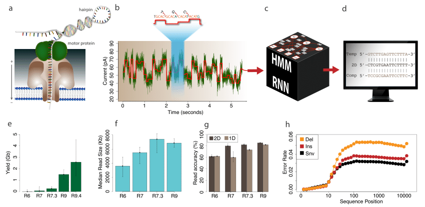